# Part I - (Prosper Loan Data Exploration)

## Introduction

> The Prosper Loan Data is a dataset which contains 113937 loans and each loan has 81 variables. Some of the variables in the dataset are loan amount, income range, loan status, borrower rate and listing category.

## Preliminary Wrangling

```python
# import all packages and set plots to be embedded inline
import numpy as np
import pandas as pd
import matplotlib.pyplot as plt
import seaborn as sb

%matplotlib inline
```

> Load in your dataset and describe its properties through the questions below. Try and motivate your exploration goals through this section.

```python
# load in the dataset into a pandas dataframe, print statistics
loan_data = pd.read_csv('prosperLoanData.csv')
loan_data.info()
```

```
<class 'pandas.core.frame.DataFrame'>
RangeIndex: 113937 entries, 0 to 113936
Data columns (total 81 columns):
ListingKey                             113937 non-null object
ListingNumber                          113937 non-null int64
ListingCreationDate                    113937 non-null object
CreditGrade                            28953 non-null object
Term                                   113937 non-null int64
LoanStatus                             113937 non-null object
ClosedDate                             55089 non-null object
BorrowerAPR                            113912 non-null float64
BorrowerRate                           113937 non-null float64
LenderYield                            113937 non-null float64
EstimatedEffectiveYield                84853 non-null float64
EstimatedLoss                          84853 non-null float64
EstimatedReturn                        84853 non-null float64
ProsperRating (numeric)                84853 non-null float64
ProsperRating (Alpha)                  84853 non-null object
ProsperScore                           84853 non-null float64
ListingCategory (numeric)              113937 non-null int64
BorrowerState                          108422 non-null object
Occupation                             110349 non-null object
EmploymentStatus                       111682 non-null object
EmploymentStatusDuration               106312 non-null float64
IsBorrowerHomeowner                    113937 non-null bool
CurrentlyInGroup                       113937 non-null bool
GroupKey                               13341 non-null object
DateCreditPulled                       113937 non-null object
CreditScoreRangeLower                  113346 non-null float64
CreditScoreRangeUpper                  113346 non-null float64
FirstRecordedCreditLine                113240 non-null object
CurrentCreditLines                     106333 non-null float64
OpenCreditLines                        106333 non-null float64
TotalCreditLinespast7years             113240 non-null float64
OpenRevolvingAccounts                  113937 non-null int64
OpenRevolvingMonthlyPayment            113937 non-null float64
InquiriesLast6Months                   113240 non-null float64
TotalInquiries                         112778 non-null float64
CurrentDelinquencies                   113240 non-null float64
AmountDelinquent                       106315 non-null float64
```

[output cut: 31 more lines]

```
LP_CustomerPayments                    113937 non-null float64
LP_CustomerPrincipalPayments           113937 non-null float64
LP_InterestandFees                     113937 non-null float64
LP_ServiceFees                         113937 non-null float64
LP_CollectionFees                      113937 non-null float64
LP_GrossPrincipalLoss                  113937 non-null float64
LP_NetPrincipalLoss                    113937 non-null float64
LP_NonPrincipalRecoverypayments        113937 non-null float64
PercentFunded                          113937 non-null float64
Recommendations                        113937 non-null int64
InvestmentFromFriendsCount             113937 non-null int64
InvestmentFromFriendsAmount            113937 non-null float64
Investors                              113937 non-null int64
dtypes: bool(3), float64(50), int64(11), object(17)
memory usage: 68.1+ MB
```

```python
# high-level overview of data shape and composition
print(loan_data.shape)
print(loan_data.dtypes)
print(loan_data.head(10))
```

```
(113937, 81)
ListingKey                              object
ListingNumber                            int64
ListingCreationDate                     object
CreditGrade                             object
Term                                     int64
LoanStatus                              object
ClosedDate                              object
BorrowerAPR                            float64
BorrowerRate                           float64
LenderYield                            float64
EstimatedEffectiveYield                float64
EstimatedLoss                          float64
EstimatedReturn                        float64
ProsperRating (numeric)                float64
ProsperRating (Alpha)                   object
ProsperScore                           float64
ListingCategory (numeric)                int64
BorrowerState                           object
Occupation                              object
EmploymentStatus                        object
EmploymentStatusDuration               float64
IsBorrowerHomeowner                       bool
CurrentlyInGroup                          bool
GroupKey                                object
DateCreditPulled                        object
CreditScoreRangeLower                  float64
CreditScoreRangeUpper                  float64
FirstRecordedCreditLine                 object
CurrentCreditLines                     float64
OpenCreditLines                        float64
                                        ...
TotalProsperLoans                      float64
TotalProsperPaymentsBilled             float64
OnTimeProsperPayments                  float64
ProsperPaymentsLessThanOneMonthLate    float64
ProsperPaymentsOneMonthPlusLate        float64
ProsperPrincipalBorrowed               float64
ProsperPrincipalOutstanding            float64
ScorexChangeAtTimeOfListing            float64
```

[output cut: 81 more lines]

```
9            1.0                0                          0

  InvestmentFromFriendsAmount Investors
0                         0.0       258
1                         0.0         1
2                         0.0        41
3                         0.0       158
4                         0.0        20
5                         0.0         1
6                         0.0         1
7                         0.0         1
8                         0.0         1
9                         0.0         1

[10 rows x 81 columns]
```

```python
# Converting the loan origination date column to datetime type
loan_data['LoanOriginationDate'] = pd.to_datetime(loan_data['LoanOriginationDate'])
```

```python
# Creating a listing category column with the categories being strings
list_category={0:'Not Available', 1:'Debt Consolidation', 2:'Home Improvement', 3:'Business', 4:'Personal Loan', 5:'Student Use',
 6:'Auto', 7:'Other', 8:'Baby&Adoption', 9:'Boat', 10:'Cosmetic Procedure', 11:'Engagement Ring', 12:'Green Loans',
 13:'Household Expenses', 14:'Large Purchases', 15:'Medical/Dental', 16:'Motorcycle', 17:'RV', 18:'Taxes', 19:'Vacation',
 20:'Wedding Loans'}

categories = []
for i in range(len(loan_data)):
    categories.append(list_category[loan_data['ListingCategory (numeric)'][i]])

loan_data['ListingCategory']=categories
```

```python
# Creating a column with only quarter
quarters = []
for i in range(len(loan_data)):
    quarters.append(loan_data['LoanOriginationQuarter'][i][0:2])

loan_data['OriginationQuarter'] = quarters
loan_data['OriginationQuarter']
```

```
0         Q3
1         Q1
2         Q1
3         Q4
4         Q3
5         Q4
6         Q2
7         Q2
8         Q4
9         Q4
10        Q2
11        Q4
12        Q1
13        Q3
14        Q2
```

[output cut: 47 more lines]

```python
# Converting loan status, income verifiable, is borrower homeowner and listing category columns to category type
categories = ['LoanStatus', 'IncomeVerifiable', 'IsBorrowerHomeowner', 'ListingCategory']
for category in categories:
    loan_data[category] = loan_data[category].astype('category')

print(loan_data.dtypes)
```

```
ListingKey                                     object
ListingNumber                                   int64
ListingCreationDate                            object
CreditGrade                                    object
Term                                            int64
LoanStatus                                   category
ClosedDate                                     object
BorrowerAPR                                   float64
BorrowerRate                                  float64
LenderYield                                   float64
EstimatedEffectiveYield                       float64
EstimatedLoss                                 float64
EstimatedReturn                               float64
ProsperRating (numeric)                       float64
ProsperRating (Alpha)                          object
ProsperScore                                  float64
ListingCategory (numeric)                       int64
BorrowerState                                  object
Occupation                                     object
EmploymentStatus                               object
EmploymentStatusDuration                      float64
IsBorrowerHomeowner                          category
CurrentlyInGroup                                 bool
GroupKey                                       object
DateCreditPulled                               object
CreditScoreRangeLower                         float64
CreditScoreRangeUpper                         float64
FirstRecordedCreditLine                        object
CurrentCreditLines                            float64
OpenCreditLines                               float64
                                            ...
OnTimeProsperPayments                         float64
ProsperPaymentsLessThanOneMonthLate           float64
ProsperPaymentsOneMonthPlusLate               float64
ProsperPrincipalBorrowed                      float64
ProsperPrincipalOutstanding                   float64
ScorexChangeAtTimeOfListing                   float64
LoanCurrentDaysDelinquent                       int64
LoanFirstDefaultedCycleNumber                 float64
LoanMonthsSinceOrigination                      int64
LoanNumber                                      int64
LoanOriginalAmount                              int64
LoanOriginationDate                    datetime64[ns]
LoanOriginationQuarter                         object
MemberKey                                      object
MonthlyLoanPayment                            float64
LP_CustomerPayments                           float64
LP_CustomerPrincipalPayments                  float64
LP_InterestandFees                            float64
LP_ServiceFees                                float64
LP_CollectionFees                             float64
LP_GrossPrincipalLoss                         float64
LP_NetPrincipalLoss                           float64
LP_NonPrincipalRecoverypayments               float64
PercentFunded                                 float64
Recommendations                                 int64
InvestmentFromFriendsCount                      int64
InvestmentFromFriendsAmount                   float64
Investors                                       int64
ListingCategory                              category
OriginationQuarter                             object
Length: 83, dtype: object
```

```python
# descriptive statistics for numeric variables
print(loan_data.describe())
```

```
       ListingNumber           Term    BorrowerAPR   BorrowerRate  \
count   1.139370e+05  113937.000000  113912.000000  113937.000000
mean    6.278857e+05      40.830248       0.218828       0.192764
std     3.280762e+05      10.436212       0.080364       0.074818
min     4.000000e+00      12.000000       0.006530       0.000000
25%     4.009190e+05      36.000000       0.156290       0.134000
50%     6.005540e+05      36.000000       0.209760       0.184000
75%     8.926340e+05      36.000000       0.283810       0.250000
max     1.255725e+06      60.000000       0.512290       0.497500

         LenderYield  EstimatedEffectiveYield  EstimatedLoss  EstimatedReturn  \
count  113937.000000             84853.000000   84853.000000     84853.000000
mean        0.182701                 0.168661       0.080306         0.096068
std         0.074516                 0.068467       0.046764         0.030403
min        -0.010000                -0.182700       0.004900        -0.182700
25%         0.124200                 0.115670       0.042400         0.074080
50%         0.173000                 0.161500       0.072400         0.091700
75%         0.240000                 0.224300       0.112000         0.116600
max         0.492500                 0.319900       0.366000         0.283700

       ProsperRating (numeric)  ProsperScore      ...        LP_ServiceFees  \
count             84853.000000  84853.000000      ...         113937.000000
mean                  4.072243      5.950067      ...            -54.725641
std                   1.673227      2.376501      ...             60.675425
min                   1.000000      1.000000      ...           -664.870000
25%                   3.000000      4.000000      ...            -73.180000
50%                   4.000000      6.000000      ...            -34.440000
75%                   5.000000      8.000000      ...            -13.920000
max                   7.000000     11.000000      ...             32.060000

       LP_CollectionFees  LP_GrossPrincipalLoss  LP_NetPrincipalLoss  \
count      113937.000000          113937.000000        113937.000000
mean          -14.242698             700.446342           681.420499
std           109.232758            2388.513831          2357.167068
min         -9274.750000             -94.200000          -954.550000
25%             0.000000               0.000000             0.000000
50%             0.000000               0.000000             0.000000
75%             0.000000               0.000000             0.000000
max             0.000000           25000.000000         25000.000000

       LP_NonPrincipalRecoverypayments  PercentFunded  Recommendations  \
count                    113937.000000  113937.000000    113937.000000
mean                         25.142686       0.998584         0.048027
std                         275.657937       0.017919         0.332353
min                           0.000000       0.700000         0.000000
25%                           0.000000       1.000000         0.000000
50%                           0.000000       1.000000         0.000000
75%                           0.000000       1.000000         0.000000
max                       21117.900000       1.012500        39.000000

       InvestmentFromFriendsCount  InvestmentFromFriendsAmount      Investors
count               113937.000000                113937.000000  113937.000000
mean                     0.023460                    16.550751      80.475228
std                      0.232412                   294.545422     103.239020
min                      0.000000                     0.000000       1.000000
25%                      0.000000                     0.000000       2.000000
50%                      0.000000                     0.000000      44.000000
75%                      0.000000                     0.000000     115.000000
max                     33.000000                 25000.000000    1189.000000

[8 rows x 61 columns]
```

### What is the structure of your dataset?

> There are 113,937 loans in the dataset with 81 variables. Most variables are numeric in nature. The dataset can be found [here](https://s3.amazonaws.com/udacity-hosted-downloads/ud651/prosperLoanData.csv) and the feature documentation can be found [here](https://docs.google.com/spreadsheets/d/1gDyi_L4UvIrLTEC6Wri5nbaMmkGmLQBk-Yx3z0XDEtI/edit#gid=0)

### What is/are the main feature(s) of interest in your dataset?

> I am interested in finding out the factors that affect the original loan amount.

### What features in the dataset do you think will help support your investigation into your feature(s) of interest?

> The features in the dataset which I think will help support my investigation into the original loan amount are income range, loan status, monthly income, income verifiable, months since origination, origination quarter, origination date, is borrower homeowner, term, borrow rate, listing category and monthly loan payment.

## Univariate Exploration

> In this section, investigate distributions of individual variables. If you see unusual points or outliers, take a deeper look to clean things up and prepare yourself to look at relationships between variables.

I'll start by looking at the distribution of the main variable of interest: original amount.

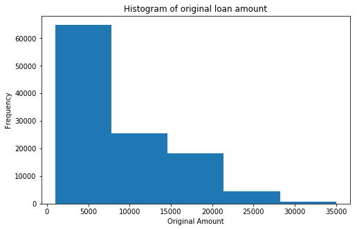

```python
# Plotting a histogram for original loan amount
plt.figure(figsize=[8, 5])
base_color = sb.color_palette()[0]
loan_data['LoanOriginalAmount'].hist(bins=5, grid=False, color=base_color)

plt.title('Histogram of original loan amount')
plt.xlabel('Original Amount')
plt.ylabel('Frequency')
plt.show()
```

Increasing the number of bins

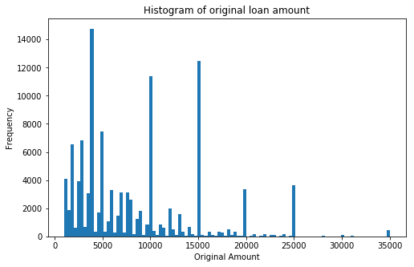

```python
# Plotting a histogram for original loan amount with more bins
plt.figure(figsize=[8, 5])
base_color = sb.color_palette()[0]
loan_data['LoanOriginalAmount'].hist(bins=100, grid=False)

plt.title('Histogram of original loan amount')
plt.xlabel('Original Amount')
plt.ylabel('Frequency')
plt.show()
```

Generally most of the loans have a smaller amount and the number of loans starts decreasing as the original loan amount increases. There are some peaks along the way.

Looking at the distribution of the other variables

```python
# Function to plot bar graphs
def plot_bar(x):
    plt.figure(figsize=[8, 5])
    base_color = sb.color_palette()[0]
    loan_data[x].value_counts().plot(kind='bar', color=base_color)
    plt.title('Bar graph of {}'.format(x))
    plt.xlabel(x)
    plt.ylabel('Frequency')
    plt.xticks(rotation=90)
    plt.show()
```

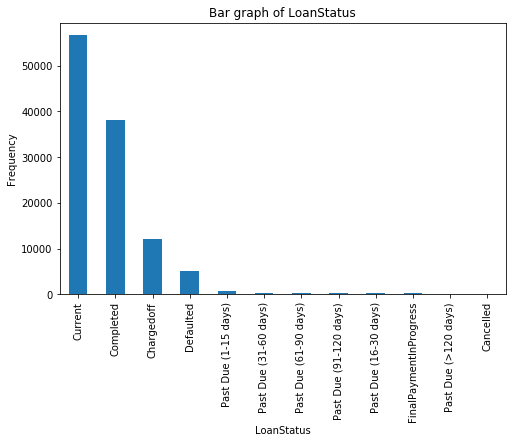

```python
# looking at the distribution of loan status.
plot_bar(x = 'LoanStatus')
```

It can be seen from the bar graph that majority of loans are still current followed by completed loans and cancelled loans have the least frequency.

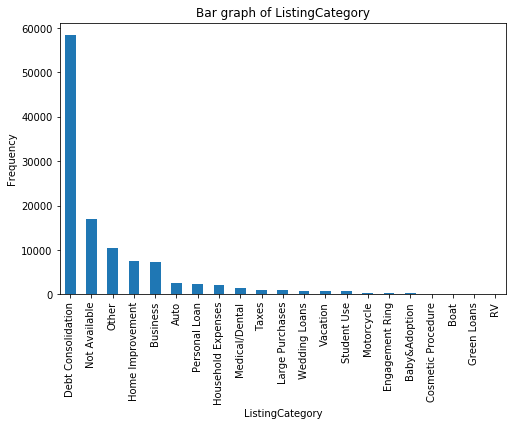

```python
# looking at the distribution of listing category.
plot_bar(x = 'ListingCategory')
```

Most people borrowed money to consolidate their loans, followed by not available and the least number of people borrowed for RV. It can be seen that as the number of people decreases the loans become more luxurious.

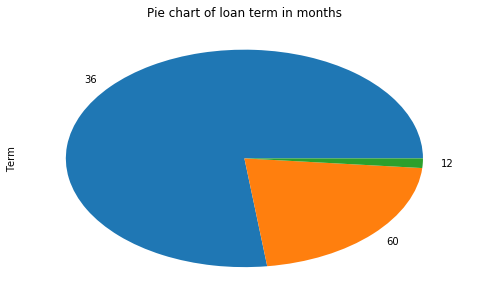

```python
# Looking at the distribution of loan term
loan_term = loan_data['Term'].value_counts()

plt.figure(figsize=[8, 5])
loan_term.plot(kind='pie')
plt.title('Pie chart of loan term in months')
plt.show()
```

It can be seen from the pie chart that the length of most loans is 36 months, followed by 60 months and lastly 12 months.

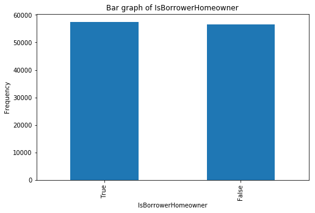

```python
# Looking at the distribution for is borrower homeowner
plot_bar(x = 'IsBorrowerHomeowner')
```

The number of borrowers who are homeowners and who are non-homeowners is equally distributed

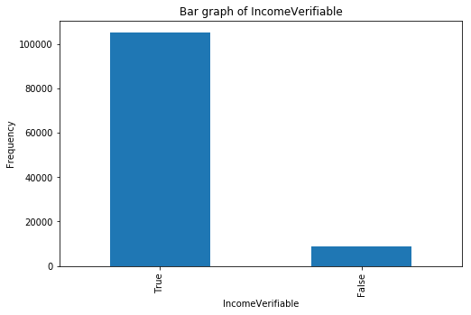

```python
# Looking at the distribution for income verifiable
plot_bar(x = 'IncomeVerifiable')
```

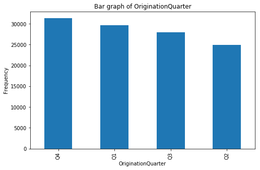

```python
# Looking at the distribution for quarter
plot_bar(x = 'OriginationQuarter')
```

Most people borrow money in the last quarter as compared to all the other quarters and the second quarter has the least number of people who borrow money

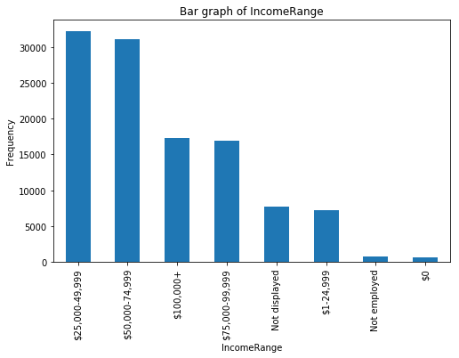

```python
# Looking at the distribution for quarter
plot_bar(x = 'IncomeRange')
```

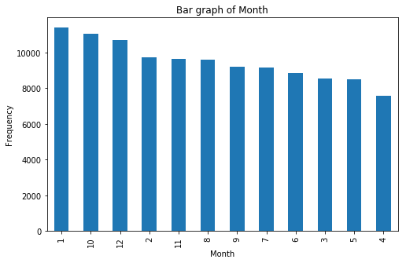

```python
# Extracting the month from the date column
loan_data['Month'] = loan_data['LoanOriginationDate'].dt.month

# Looking at the distribution for month
plot_bar(x = 'Month')
```

January is the month when most people borrow money followed by october then december and april is the month with the least number of people who borrow money

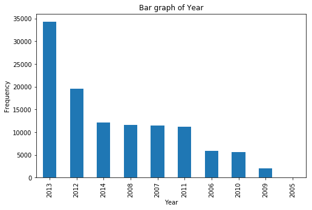

```python
# Extracting the year from the date column
loan_data['Year'] = loan_data['LoanOriginationDate'].dt.year

# Looking at the distribution for year
plot_bar(x = 'Year')
```

2013 has the most number of people who got a loan, followed by 2012 and 2014 respectively. 2005 got the least number number of people who borrowed money

### Of the features you investigated, were there any unusual distributions? Did you perform any operations on the data to tidy, adjust, or change the form of the data? If so, why did you do this?

> It was quite unsual that the term with the highest number of loans was 36 months since it would be more logical to give out more short term loans like a term of 12 months. These short term loans ensure that the money is returned in no time and this money can be loaned out to other people. It was also surprising to note that the number of homeowners and non-homeowners who got a loan was roughly the same, it would have been more sensible for people who are not homeowners to be more than homeowners. The loan origination date feature was converted from object type to datetime and features like is borrower homeowner, listing category, income verifiable and loan status were converted to categorical type. Other features such as month and year were created to aid with the exploration.

## Bivariate Exploration

> In this section, investigate relationships between pairs of variables in your data. Make sure the variables that you cover here have been introduced in some fashion in the previous section (univariate exploration).

To start off with, I want to look at the pairwise correlations present between features in the data.

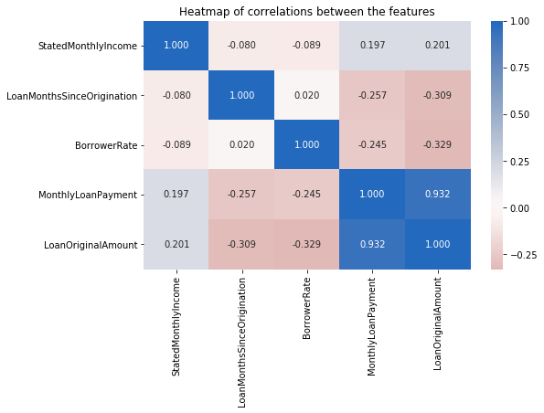

```python
num_vars = ['StatedMonthlyIncome', 'LoanMonthsSinceOrigination', 'BorrowerRate', 'MonthlyLoanPayment',
           'LoanOriginalAmount']

# correlation plot
plt.figure(figsize = [8, 5])
sb.heatmap(loan_data[num_vars].corr(), annot = True, fmt = '.3f',
           cmap = 'vlag_r', center = 0)
plt.title('Heatmap of correlations between the features')
plt.show()
```

Monthly loan payment is very highly correlated with the original loan amount which makes sense since if the original loan amount is high then the money that is paid back has to be high as well. The other variables such as borrower rate, loan months since origination and stated monthly income have a weak correlation with the variable of interest which is original loan amount.

Checking the pairwise relationship between the variables using a scatter plot

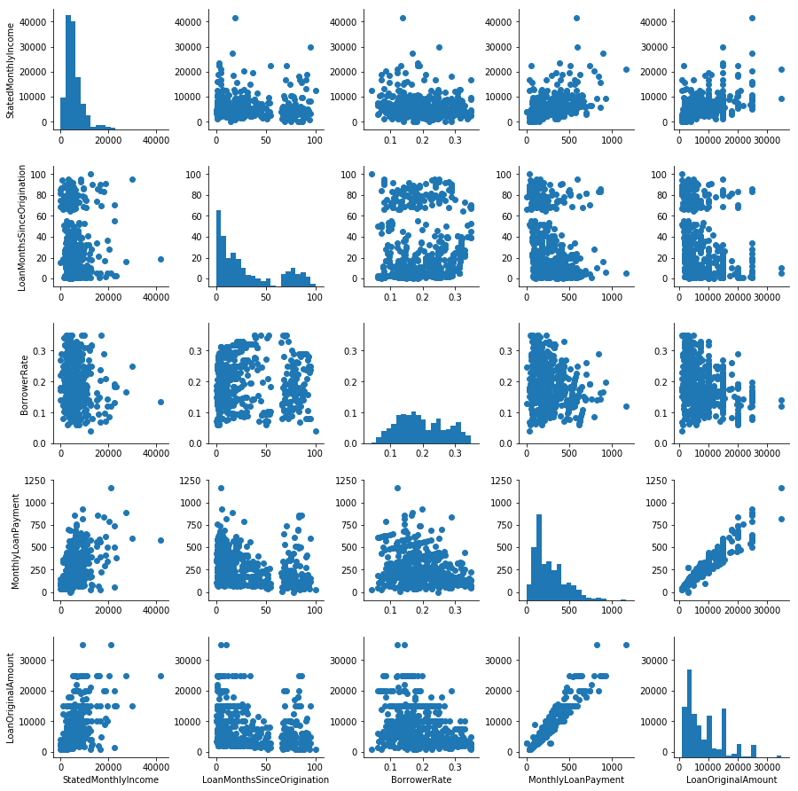

```python
# plot matrix: sample 500 loans so that plots are clearer and they render faster
loan_sample = loan_data.sample(n=500, replace=False)
g = sb.PairGrid(data = loan_sample, vars = num_vars)
g = g.map_diag(plt.hist, bins = 20);
g.map_offdiag(plt.scatter)
plt.show();
```

In the plots shown above the only two variables which have a strong relationship between them are original loan amount and monthly loan payment whose relationship looks linear hence the reason why the correlation between the two variables was high. All the other variables show a week relationship between each other hence the low correlation between the variables.

Checking the relationship between monthly loan payment and original loan amount since the correlation between the variables was high

```python
# Function used to plot scatter plots of original loan amount with the other variables
def plot_scatter(x, y):
    plt.figure(figsize = [8, 6])
    plt.scatter(data = loan_data, x = x, y = y, alpha = 1/10)
    plt.title('Scatter plot of {} against {}'.format(y, x))
    plt.xlabel(x)
    plt.ylabel(y)
    plt.show()
```

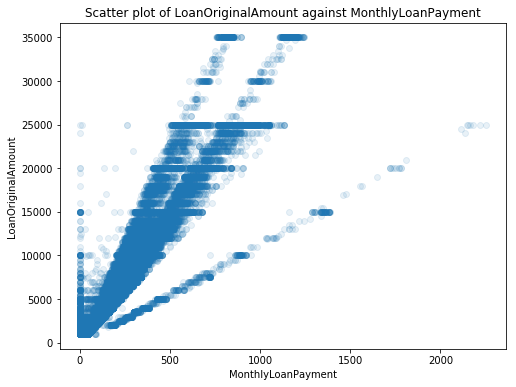

```python
# scatter plot of original loan amount vs. monthly loan payment
plot_scatter(x = 'MonthlyLoanPayment', y = 'LoanOriginalAmount')
```

In general as the monthly loan amount increases the original loan amount also increases

Checking the relationship between stated monthly income and original loan amount

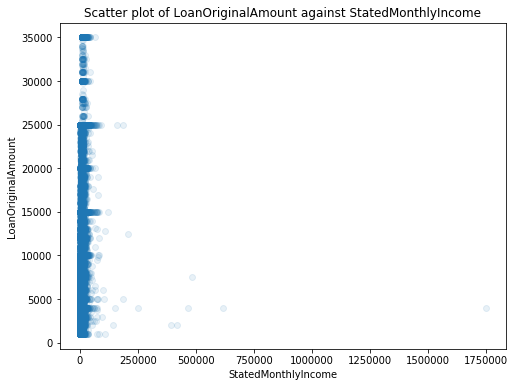

```python
# scatter plot of original loan amount vs. stated monthly income
plot_scatter(x = 'StatedMonthlyIncome', y = 'LoanOriginalAmount')
```

People with low stated monthly income tend to be the ones that borrow more as compared to people with high stated monthly income

Checking the relationship between borrower rate and original loan amount

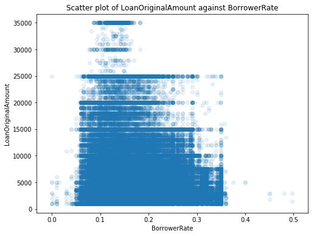

```python
# scatter plot of original loan amount vs. borrower rate
plot_scatter(x = 'BorrowerRate', y = 'LoanOriginalAmount')
```

For lower original loan amounts the borrower rate has the greatest variation but as the amount increases the rate tends to be lower. Generally as the original loan amount increases the borrower rate decreases this is why borrower rate and original loan amount have a negative correlation.

Checking how variables changed over time

```python
# Sorting the dataframe by loan origination date
loan_sort = loan_data.sort_values(by='LoanOriginationDate')

def time_series(y):
    plt.figure(figsize = [8, 6])
    plt.plot(loan_sort['LoanOriginationDate'], loan_sort[y])
    plt.title('Time series of {} against the loan origination date'.format(y))
    plt.xlabel('Loan Origination Date')
    plt.ylabel(y)
    plt.show()
```

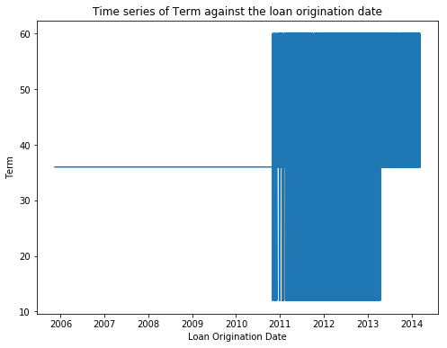

```python
# Time series for term
time_series(y = 'Term')
```

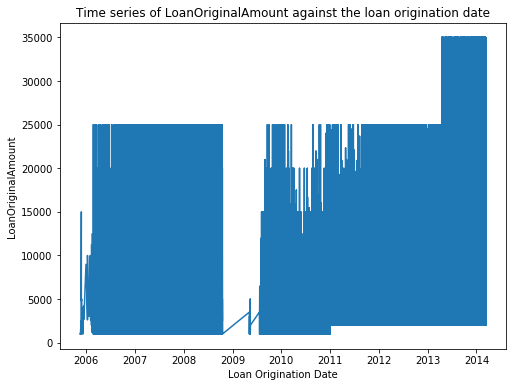

```python
# Time series for original loan amount
time_series(y='LoanOriginalAmount')
```

There is no pattern that can noticed form this plot as the trendline is just moving up and down

Checking further the trend for the average original loan amount per year

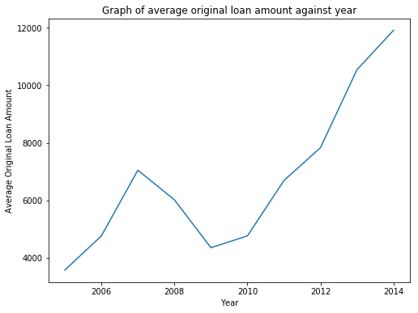

```python
plt.figure(figsize = [8, 6])
loan_data.groupby('Year').mean()['LoanOriginalAmount'].plot()
plt.title('Graph of average original loan amount against year')
plt.xlabel('Year')
plt.ylabel('Average Original Loan Amount')
plt.show()
```

The general trend is that the average original loan amount that is borrowed increases as the years progress

Checking whether being a homeowner helps in getting a long term to pay back the loan

```python
# Function to plot 2d bar graph
def plot_bar_2d(x, y):
    plt.figure(figsize = [8, 6])
    sb.countplot(data = loan_data, x = x, hue = y)
    plt.title('Bar graph of {} divided over {}'.format(x,y))
    plt.xticks(rotation=90)
    plt.show()
```

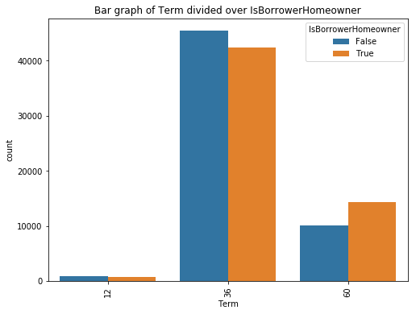

```python
# Plotting a bar graph of term divided over is borrower owner
plot_bar_2d(x = 'Term', y = 'IsBorrowerHomeowner')
```

People who are not homeowners tend to be given shorter terms to pay back the loan as compared to people who are homeowners

Checking whether homeowners are the ones that get loans for luxury such as buying a boat

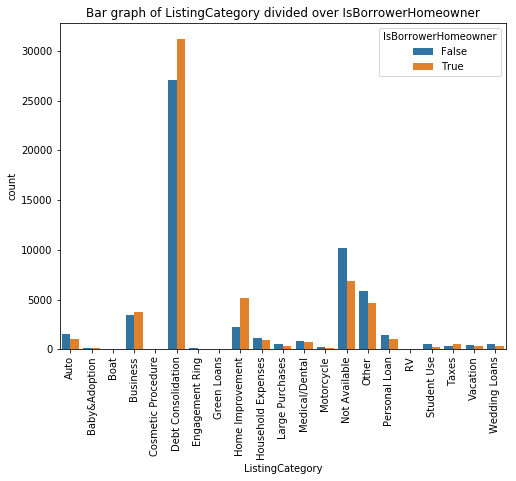

```python
# Plotting a bar graph of term divided over is borrower owner
plot_bar_2d(x = 'ListingCategory', y = 'IsBorrowerHomeowner')
```

The pattern is not clear since sometimes homeowners are more than in certain listing category and vice-versa

```python
# Fucntion to create a box plot
def box_plot(x,y, **kwargs):
    base_color = sb.color_palette()[0]
    sb.boxplot(data = loan_data, x = x, y = y,
                      color = base_color)
```

Checking the distribution of original loan amount for variables such as income verifiable, is borrower homeowner and term

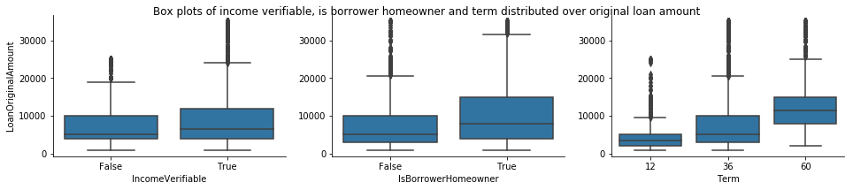

```python
categoric_vars = ['IncomeVerifiable', 'IsBorrowerHomeowner', 'Term']

g = sb.PairGrid(data = loan_data, y_vars = ['LoanOriginalAmount'], x_vars = categoric_vars,
                size = 3, aspect = 1.5)
g.map(box_plot)
plt.suptitle('Box plots of income verifiable, is borrower homeowner and term distributed over original loan amount')
plt.tight_layout()
plt.show();
```

As can be seen in the figure above, the original loan amount generally increases if the income is verifiable, the borrower is a homeowner and the term to payback the loan is longer.

### Talk about some of the relationships you observed in this part of the investigation. How did the feature(s) of interest vary with other features in the dataset?

> For the features that are numeric, only original loan amount and monthly loan payment had a strong relationship with each other. This was confirmed by plotting scatter plots of all the features with each other using 500 samples to make it more legible. Other features such as stated monthly income, loan months since origination and borrower rate did not show any pattern between between each other. Only monthly loan payment and original loan amount had a linear relationship. It was noted that the average original loan amount increased as the years progressed. It was also noted that the original loan amount increases as the borrower has a verifiable income, is a homeowner and needs a longer term to pay the loan.

## Multivariate Exploration

> Create plots of three or more variables to investigate your data even further. Make sure that your investigations are justified, and follow from your work in the previous sections.

Checking for the relationship between original loan amount, monthly loan payment and term

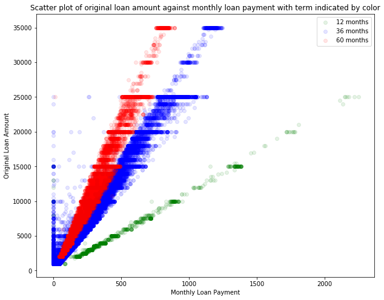

```python
term_col = [[12, 'g'], [36, 'b'], [60, 'r']]
plt.figure(figsize = [10, 8])
for term, col in term_col:
    df = loan_data[loan_data['Term']==term]
    plt.scatter(df['MonthlyLoanPayment'], df['LoanOriginalAmount'], alpha = 1/10, color=col)
plt.title('Scatter plot of original loan amount against monthly loan payment with term indicated by color')
plt.xlabel('Monthly Loan Payment')
plt.ylabel('Original Loan Amount')
plt.legend(['12 months', '36 months', '60 months'])
plt.show()
```

It can be seen in the scatter plot above that the relationship between original loan amount and monthly loan payment is linear and the reason why it looks as if there are 3 lines in the figure is because each of these points clustered close together represent a different term which can be seen from the different colors in the figure.

Checking for the relationship between average original loan amount, year and term

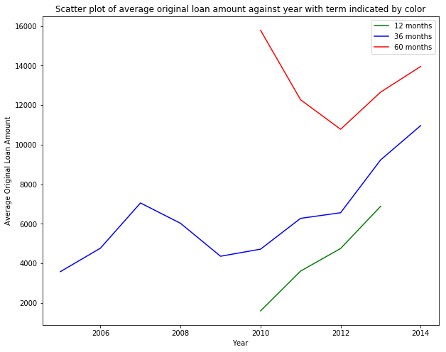

```python
term_col = [[12, 'g'], [36, 'b'], [60, 'r']]
plt.figure(figsize = [10, 8])
for term, col in (term_col):
    plt.plot(loan_data.groupby(['Term','Year']).mean()['LoanOriginalAmount'][term], color=col)
plt.title('Scatter plot of average original loan amount against year with term indicated by color')
plt.xlabel('Year')
plt.ylabel('Average Original Loan Amount')
plt.legend(['12 months', '36 months', '60 months'])
plt.show()
```

In the plot above it can be seen that the general trend for the term of 12 and 36 months is increasing whilst for the term of 60 months it first decreases then it increases. The term of 60 months has the highest average original loan amount, followed by the term of 36 months and lastly the term of 12 months for the years where all 3 terms have values.

### Talk about some of the relationships you observed in this part of the investigation. Were there features that strengthened each other in terms of looking at your feature(s) of interest?

> Original loan amount and monthly loan payment have a very strong relationship and by conducting mutlivariate exploration it was discovered that the scatter plot can be divided into 3 sections one for the term of 12 months, another one for the term of 36 months and the last one for the term of 60 months. It can also be seen from the gradient of these 3 sections that if the term is longer then the amount paid per month is lower is there is more time to pay. By plotting the average original loan amount against year and separating the plots by term it was discovered that the term of 60 months always has the highest average original loan amount followed by the term of 36 months and lastly the term of 12 months.

### Were there any interesting or surprising interactions between features?

> It was very interesting to note that the scatter plot of original loan amount and monthly loan payment could be divided into sections by coloring the datapoints using the term feature. It made it easier to understand that a person with a longer term pays less money per month as compared to someone whose term is shorter. It was also interesting to note that the average original loan amount for a longer term is always higher than that for a short term.

## Conclusions

> It was discovered that original loan amount and monthly loan payment have a strong relationship. It was further discovered that this relationship is even stronger if only one term is used for each plot since the scatter plot is split into 3 sections using the term represented by different colors. The other numerical features did not have a strong relationship with original loan amount which is the feature of interest as other features. It was also observed that the original loan amount generally increases if the income is verifiable, the borrower is a homeowner and the term to payback the loan is longer.

> The first step was to make sure the data is tidy and not dirty and cleaning any unclean data. The second step in the data exploration was to choose the features to use for the exploration and going on further to choose the feature of interest which is original loan amount in this case. The next step was to come up with a question, visualization and observation for each visualization in the univariate exploration, then a summary was written for all the visualizations. This step was repeated for bivariate and multivariate exploration and finally a conclusion was written for the exploration.